```python
import numpy as np
import pandas as pd
```

```python
import matplotlib.pyplot as plt
import seaborn as sns
```

# Introduction

In this notebook we will examine the Basketball datasets, and derive relationships between college player performance and success in the NBA. Specifically, we will see if NCAA data can help coaches predict how well a player might perofrm in terms of points per game, 3 point percentage, field goal percentage, and free throw percentage

```python
official_box_score = pd.read_csv("2012-18_officialBoxScore.csv")
team_box_score =  pd.read_csv("2012-18_teamBoxScore.csv")
player_box_score = pd.read_csv("2012-18_playerBoxScore.csv")
standings = pd.read_csv("2012-18_standings.csv")
college = pd.read_csv("college.csv")
```

```python
official_box_score.head()
```

|  | gmDate | gmTime | seasTyp | offLNm | offFNm | teamAbbr | teamConf | teamDiv | teamLoc | teamRslt | ... | opptFIC40 | opptOrtg | opptDrtg | opptEDiff | opptPlay% | opptAR | opptAST/TO | opptSTL/TO | poss | pace |
| --- | --- | --- | --- | --- | --- | --- | --- | --- | --- | --- | --- | --- | --- | --- | --- | --- | --- | --- | --- | --- | --- |
| 0 | 2012-10-30 | 19:00 | Regular | Brothers | Tony | WAS | East | Southeast | Away | Loss | ... | 61.6667 | 105.6882 | 94.4447 | 11.2435 | 0.4390 | 16.7072 | 1.0476 | 33.3333 | 88.9409 | 88.9409 |
| 1 | 2012-10-30 | 19:00 | Regular | Smith | Michael | WAS | East | Southeast | Away | Loss | ... | 61.6667 | 105.6882 | 94.4447 | 11.2435 | 0.4390 | 16.7072 | 1.0476 | 33.3333 | 88.9409 | 88.9409 |
| 2 | 2012-10-30 | 19:00 | Regular | Workman | Haywoode | WAS | East | Southeast | Away | Loss | ... | 61.6667 | 105.6882 | 94.4447 | 11.2435 | 0.4390 | 16.7072 | 1.0476 | 33.3333 | 88.9409 | 88.9409 |
| 3 | 2012-10-30 | 19:00 | Regular | Brothers | Tony | CLE | East | Central | Home | Win | ... | 56.0417 | 94.4447 | 105.6882 | -11.2435 | 0.3765 | 18.8679 | 2.0000 | 84.6154 | 88.9409 | 88.9409 |
| 4 | 2012-10-30 | 19:00 | Regular | Smith | Michael | CLE | East | Central | Home | Win | ... | 56.0417 | 94.4447 | 105.6882 | -11.2435 | 0.3765 | 18.8679 | 2.0000 | 84.6154 | 88.9409 | 88.9409 |

5 rows × 119 columns

```python
team_box_score.head()
```

|  | gmDate | gmTime | seasTyp | offLNm1 | offFNm1 | offLNm2 | offFNm2 | offLNm3 | offFNm3 | teamAbbr | ... | opptFIC40 | opptOrtg | opptDrtg | opptEDiff | opptPlay% | opptAR | opptAST/TO | opptSTL/TO | poss | pace |
| --- | --- | --- | --- | --- | --- | --- | --- | --- | --- | --- | --- | --- | --- | --- | --- | --- | --- | --- | --- | --- | --- |
| 0 | 2012-10-30 | 19:00 | Regular | Brothers | Tony | Smith | Michael | Workman | Haywoode | WAS | ... | 61.6667 | 105.6882 | 94.4447 | 11.2435 | 0.4390 | 16.7072 | 1.0476 | 33.3333 | 88.9409 | 88.9409 |
| 1 | 2012-10-30 | 19:00 | Regular | Brothers | Tony | Smith | Michael | Workman | Haywoode | CLE | ... | 56.0417 | 94.4447 | 105.6882 | -11.2435 | 0.3765 | 18.8679 | 2.0000 | 84.6154 | 88.9409 | 88.9409 |
| 2 | 2012-10-30 | 20:00 | Regular | McCutchen | Monty | Wright | Sean | Fitzgerald | Kane | BOS | ... | 80.8333 | 126.3381 | 112.6515 | 13.6866 | 0.5244 | 19.8287 | 3.1250 | 100.0000 | 94.9832 | 94.9832 |
| 3 | 2012-10-30 | 20:00 | Regular | McCutchen | Monty | Wright | Sean | Fitzgerald | Kane | MIA | ... | 62.7083 | 112.6515 | 126.3381 | -13.6866 | 0.4643 | 18.8501 | 1.5000 | 25.0000 | 94.9832 | 94.9832 |
| 4 | 2012-10-30 | 22:30 | Regular | Foster | Scott | Zielinski | Gary | Dalen | Eric | DAL | ... | 58.6458 | 99.3678 | 108.1034 | -8.7356 | 0.5000 | 18.6567 | 1.7143 | 42.8571 | 91.5790 | 91.5790 |

5 rows × 123 columns

```python
player_box_score.head()
```

|  | gmDate | gmTime | seasTyp | playLNm | playFNm | teamAbbr | teamConf | teamDiv | teamLoc | teamRslt | ... | playFT% | playORB | playDRB | playTRB | opptAbbr | opptConf | opptDiv | opptLoc | opptRslt | opptDayOff |
| --- | --- | --- | --- | --- | --- | --- | --- | --- | --- | --- | --- | --- | --- | --- | --- | --- | --- | --- | --- | --- | --- |
| 0 | 2012-10-30 | 19:00 | Regular | Price | A.J. | WAS | East | Southeast | Away | Loss | ... | 1.0 | 1 | 1 | 2 | CLE | East | Central | Home | Win | 0 |
| 1 | 2012-10-30 | 19:00 | Regular | Ariza | Trevor | WAS | East | Southeast | Away | Loss | ... | 0.5 | 1 | 2 | 3 | CLE | East | Central | Home | Win | 0 |
| 2 | 2012-10-30 | 19:00 | Regular | Okafor | Emeka | WAS | East | Southeast | Away | Loss | ... | 0.5 | 5 | 2 | 7 | CLE | East | Central | Home | Win | 0 |
| 3 | 2012-10-30 | 19:00 | Regular | Beal | Bradley | WAS | East | Southeast | Away | Loss | ... | 1.0 | 0 | 3 | 3 | CLE | East | Central | Home | Win | 0 |
| 4 | 2012-10-30 | 19:00 | Regular | Booker | Trevor | WAS | East | Southeast | Away | Loss | ... | 0.0 | 1 | 0 | 1 | CLE | East | Central | Home | Win | 0 |

5 rows × 51 columns

```python
standings.head()
```

|  | stDate | teamAbbr | rank | rankOrd | gameWon | gameLost | stk | stkType | stkTot | gameBack | ... | rel%Indx | mov | srs | pw% | pyth%13.91 | wpyth13.91 | lpyth13.91 | pyth%16.5 | wpyth16.5 | lpyth16.5 |
| --- | --- | --- | --- | --- | --- | --- | --- | --- | --- | --- | --- | --- | --- | --- | --- | --- | --- | --- | --- | --- | --- |
| 0 | 2012-10-30 | ATL | 3 | 3rd | 0 | 0 | - | - | 0 | 0.5 | ... | 0.0 | 0.0 | 0.0 | 0.500 | 0.0000 | 0.0000 | 82.0000 | 0.000 | 0.000 | 82.000 |
| 1 | 2012-10-30 | BKN | 3 | 3rd | 0 | 0 | - | - | 0 | 0.5 | ... | 0.0 | 0.0 | 0.0 | 0.500 | 0.0000 | 0.0000 | 82.0000 | 0.000 | 0.000 | 82.000 |
| 2 | 2012-10-30 | BOS | 14 | 14th | 0 | 1 | L1 | loss | 1 | 1.0 | ... | 0.0 | -13.0 | -13.0 | 0.072 | 0.1687 | 13.8334 | 68.1666 | 0.131 | 10.742 | 71.258 |
| 3 | 2012-10-30 | CHA | 3 | 3rd | 0 | 0 | - | - | 0 | 0.5 | ... | 0.0 | 0.0 | 0.0 | 0.500 | 0.0000 | 0.0000 | 82.0000 | 0.000 | 0.000 | 82.000 |
| 4 | 2012-10-30 | CHI | 3 | 3rd | 0 | 0 | - | - | 0 | 0.5 | ... | 0.0 | 0.0 | 0.0 | 0.500 | 0.0000 | 0.0000 | 82.0000 | 0.000 | 0.000 | 82.000 |

5 rows × 39 columns

```python
college.head()
```

|  | Unnamed: 0 | active_from | active_to | birth_date | college | height | name | position | url | weight | ... | NCAA__3ptpg | NCAA_efgpct | NCAA_fgapg | NCAA_fgpct | NCAA_fgpg | NCAA_ft | NCAA_ftapg | NCAA_ftpg | NCAA_games | NCAA_ppg |
| --- | --- | --- | --- | --- | --- | --- | --- | --- | --- | --- | --- | --- | --- | --- | --- | --- | --- | --- | --- | --- | --- |
| 0 | 0 | 1991 | 1995 | June 24, 1968 | Duke University | 6-10 | Alaa Abdelnaby | F-C | /players/a/abdelal01.html | 240.0 | ... | 0.0 | NaN | 5.6 | 0.599 | 3.3 | 0.728 | 2.5 | 1.8 | 134.0 | 8.5 |
| 1 | 1 | 1969 | 1978 | April 7, 1946 | Iowa State University | 6-9 | Zaid Abdul-Aziz | C-F | /players/a/abdulza01.html | 235.0 | ... | NaN | NaN | NaN | NaN | NaN | NaN | NaN | NaN | NaN | NaN |
| 2 | 2 | 1970 | 1989 | April 16, 1947 | University of California, Los Angeles | 7-2 | Kareem Abdul-Jabbar | C | /players/a/abdulka01.html | 225.0 | ... | NaN | NaN | 16.8 | 0.639 | 10.7 | 0.628 | 7.9 | 5.0 | 88.0 | 26.4 |
| 3 | 3 | 1991 | 2001 | March 9, 1969 | Louisiana State University | 6-1 | Mahmoud Abdul-Rauf | G | /players/a/abdulma02.html | 162.0 | ... | 2.7 | NaN | 21.9 | 0.474 | 10.4 | 0.863 | 6.4 | 5.5 | 64.0 | 29.0 |
| 4 | 4 | 1998 | 2003 | November 3, 1974 | University of Michigan, San Jose State University | 6-6 | Tariq Abdul-Wahad | F | /players/a/abdulta01.html | 223.0 | ... | NaN | NaN | NaN | NaN | NaN | NaN | NaN | NaN | NaN | NaN |

5 rows × 34 columns

## Part 1: Data Cleaning

For determing how college determines NBA success, we will combine the college dataset with nba statistics that we care about, joining on the name of the player. First, let us remove the columns from the college dataset with a lot of null values. We will also drop unncessary columns

```python
college.shape
```

```
(4576, 34)
```

We see that the college dataset has 4576 players, and has 34 attributes for each player. Let's see which of these columns has many null values

```python
college.isna().mean()
```

```
Unnamed: 0          0.000000
active_from         0.000000
active_to           0.000000
birth_date          0.006337
college             0.065997
height              0.000219
name                0.000000
position            0.000219
url                 0.000000
weight              0.001311
NBA__3ptapg         0.246503
NBA__3ptpct         0.354677
NBA__3ptpg          0.246503
NBA_efgpct          0.251311
NBA_fg%             0.006119
NBA_fg_per_game     0.000000
NBA_fga_per_game    0.000000
NBA_ft%             0.043269
NBA_ft_per_g        0.000000
NBA_fta_p_g         0.000000
NBA_g_played        0.000000
NBA_ppg             0.000000
NCAA__3ptapg        0.591783
NCAA__3ptpct        0.622815
NCAA__3ptpg         0.591128
NCAA_efgpct         1.000000
NCAA_fgapg          0.435752
NCAA_fgpct          0.435533
NCAA_fgpg           0.432255
NCAA_ft             0.433129
NCAA_ftapg          0.433566
NCAA_ftpg           0.432255
NCAA_games          0.432255
NCAA_ppg            0.432255
dtype: float64
```

We see that a good amount of these columns have many null values, so let's remove the players that don't have the NCAA information that we care about, as well as columns that are significantly empty

```python
college = college[college.columns[college.isnull().mean() < 0.5]]
```

The player college and college states is are most important featurse that we care about, so let's remove all rows that don't have a that information. Also let's remove some unnessecary columns.

```python
college.dropna(subset=['college','position', 'NCAA_fgapg', 'NCAA_fgpct',"NBA__3ptapg"], inplace=True)
college.drop(columns=['url', 'birth_date', 'Unnamed: 0', "active_from", "active_to"], inplace=True)
```

```python
college.isna().sum()
```

```
college               0
height                0
name                  0
position              0
weight                0
NBA__3ptapg           0
NBA__3ptpct         310
NBA__3ptpg            0
NBA_efgpct           15
NBA_fg%              15
NBA_fg_per_game       0
NBA_fga_per_game      0
NBA_ft%             111
NBA_ft_per_g          0
NBA_fta_p_g           0
NBA_g_played          0
NBA_ppg               0
NCAA_fgapg            0
NCAA_fgpct            0
NCAA_fgpg             0
NCAA_ft               0
NCAA_ftapg            0
NCAA_ftpg             0
NCAA_games            0
NCAA_ppg              0
dtype: int64
```

Let's fill the null quantitative values with the average value of the column

```python
college.fillna(college.mean(), inplace=True)
```

We have now fully cleaned up the data, and can now proceed with analysis of the data

## Part 2: Exploratory Data Analysis/Additional Cleaning

```python
print(college.shape)
```

```
(2536, 25)
```

We have 2536 observations, with 25 columns. First, let's see how many games most of these players play in the NBA

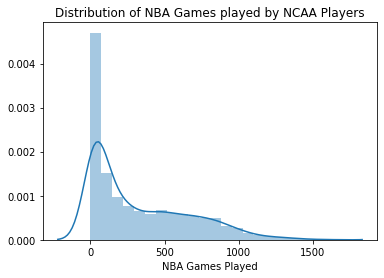

```python
sns.distplot(college['NBA_g_played'], axlabel= "NBA Games Played").set_title('Distribution of NBA Games played by NCAA Players')
```

It looks like some of these players never make it to the NBA/never get to play NBA games, so lets only keep the players that played at least 5 games

```python
college = college.loc[college['NBA_g_played'] >=5]
college.shape
```

```
(2403, 25)
```

Let's see if there's a good relationship between field goal and free throw percentage, as well as points per game in the NCAA and NBA. Unfortunately, we can't use the NCAA 3 point data since there was so little of it

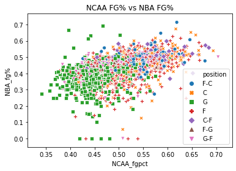

```python
ax=sns.scatterplot(x="NCAA_fgpct", y="NBA_fg%",hue= 'position', style='position', data=college).set_title('NCAA FG% vs NBA FG%')
```

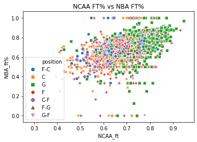

```python
sns.scatterplot(x="NCAA_ft", y="NBA_ft%",hue= 'position', style='position', data=college).set_title('NCAA FT% vs NBA FT%')
```

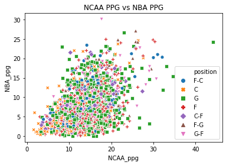

```python
sns.scatterplot(x="NCAA_ppg", y="NBA_ppg",hue= 'position', style='position', data=college).set_title('NCAA PPG vs NBA PPG')
```

There seems to be a relatively linear relationship between all of these variables, and position also appears to play a nontrivial role in both field goal percentage and free throw percentage. These relationships might be more evident if we center and standardize the data.

```python
college.college.nunique()
```

```
448
```

The college column has 448 unique values, so it might be hard to conduct analysis with it using one-hot encoding. We'll keep it for now, and remove it later if it presents an issue

Side note: one player appears to have been absolutely dominating in both the college level and the NBA in points per game, so lets quickly see who that is

```python
college[college['NCAA_ppg']>40]
```

|  | college | height | name | position | weight | NBA__3ptapg | NBA__3ptpct | NBA__3ptpg | NBA_efgpct | NBA_fg% | ... | NBA_g_played | NBA_ppg | NCAA_fgapg | NCAA_fgpct | NCAA_fgpg | NCAA_ft | NCAA_ftapg | NCAA_ftpg | NCAA_games | NCAA_ppg |
| --- | --- | --- | --- | --- | --- | --- | --- | --- | --- | --- | --- | --- | --- | --- | --- | --- | --- | --- | --- | --- | --- |
| 2539 | Louisiana State University | 6-5 | Pete Maravich | G | 197.0 | 0.3 | 0.667 | 0.2 | 0.441 | 0.441 | ... | 658 | 24.2 | 38.1 | 0.438 | 16.7 | 0.775 | 13.9 | 10.8 | 83.0 | 44.2 |

1 rows × 25 columns

The player is Pistol Pete, one of the greatest offensive players of all time, who was active in the 1970s. Also, that pink triangle at the top of the ppg plot is Michael Jordan, who went from less than 20 points per game in college to over 30 in the NBA

## Part 3: Transformations/Feature Engineering

As we concluded in the previous section, it may be useful to center and standardize the data, so we will do that now. Additonally, we will make the categorical features useful with one-hot encoding. First, lets convert the height column so that it is an int value, in inches.

```python
college["height"] = college["height"].str[:1].astype(int)*12 + college["height"].str[2:].astype(int)
college
```

|  | college | height | name | position | weight | NBA__3ptapg | NBA__3ptpct | NBA__3ptpg | NBA_efgpct | NBA_fg% | ... | NBA_g_played | NBA_ppg | NCAA_fgapg | NCAA_fgpct | NCAA_fgpg | NCAA_ft | NCAA_ftapg | NCAA_ftpg | NCAA_games | NCAA_ppg |
| --- | --- | --- | --- | --- | --- | --- | --- | --- | --- | --- | --- | --- | --- | --- | --- | --- | --- | --- | --- | --- | --- |
| 0 | Duke University | 82 | Alaa Abdelnaby | F-C | 240.0 | 0.0 | 0.000000 | 0.0 | 0.502 | 0.502 | ... | 256 | 5.7 | 5.6 | 0.599 | 3.3 | 0.728 | 2.5 | 1.8 | 134.0 | 8.5 |
| 2 | University of California, Los Angeles | 86 | Kareem Abdul-Jabbar | C | 225.0 | 0.0 | 0.056000 | 0.0 | 0.559 | 0.559 | ... | 1560 | 24.6 | 16.8 | 0.639 | 10.7 | 0.628 | 7.9 | 5.0 | 88.0 | 26.4 |
| 3 | Louisiana State University | 73 | Mahmoud Abdul-Rauf | G | 162.0 | 2.3 | 0.354000 | 0.8 | 0.472 | 0.442 | ... | 586 | 14.6 | 21.9 | 0.474 | 10.4 | 0.863 | 6.4 | 5.5 | 64.0 | 29.0 |
| 5 | University of California | 81 | Shareef Abdur-Rahim | F | 225.0 | 0.6 | 0.297000 | 0.2 | 0.479 | 0.472 | ... | 830 | 18.1 | 14.2 | 0.518 | 7.4 | 0.683 | 8.9 | 6.1 | 28.0 | 21.1 |
| 6 | Indiana University | 79 | Tom Abernethy | F | 220.0 | 0.0 | 0.000000 | 0.0 | 0.492 | 0.492 | ... | 319 | 5.6 | 4.5 | 0.533 | 2.4 | 0.689 | 1.7 | 1.1 | 110.0 | 5.9 |
| ... | ... | ... | ... | ... | ... | ... | ... | ... | ... | ... | ... | ... | ... | ... | ... | ... | ... | ... | ... | ... | ... |
| 4564 | Arizona State University | 80 | Tony Zeno | F | 210.0 | 0.0 | 0.240532 | 0.0 | 0.286 | 0.286 | ... | 8 | 1.8 | 10.4 | 0.466 | 4.8 | 0.742 | 2.4 | 1.8 | 112.0 | 11.4 |
| 4565 | Seattle Pacific University, University of Wash... | 82 | Phil Zevenbergen | C | 230.0 | 0.0 | 0.240532 | 0.0 | 0.556 | 0.556 | ... | 8 | 3.8 | 7.6 | 0.501 | 3.8 | 0.721 | 3.5 | 2.5 | 66.0 | 10.1 |
| 4567 | University of California, Los Angeles | 84 | George Zidek | C | 250.0 | 0.0 | 0.250000 | 0.0 | 0.409 | 0.408 | ... | 135 | 3.4 | 5.4 | 0.520 | 2.8 | 0.744 | 2.1 | 1.5 | 104.0 | 7.1 |
| 4569 | University of Nevada, Las Vegas | 84 | Stephen Zimmerman | C | 240.0 | 0.0 | 0.240532 | 0.0 | 0.323 | 0.323 | ... | 19 | 1.2 | 8.2 | 0.477 | 3.9 | 0.624 | 3.9 | 2.4 | 26.0 | 10.5 |
| 4572 | Kent State University | 85 | Jim Zoet | C | 240.0 | 0.0 | 0.240532 | 0.0 | 0.200 | 0.200 | ... | 7 | 0.3 | 2.9 | 0.476 | 1.4 | 0.429 | 1.0 | 0.4 | 63.0 | 3.2 |

2403 rows × 25 columns

```python
college_quant = college.select_dtypes(include=['number'])
mean = np.mean(college_quant)
std = np.std(college_quant)
college_cent_stand = (college_quant - mean)/std
college_cent_stand
```

|  | height | weight | NBA__3ptapg | NBA__3ptpct | NBA__3ptpg | NBA_efgpct | NBA_fg% | NBA_fg_per_game | NBA_fga_per_game | NBA_ft% | ... | NBA_g_played | NBA_ppg | NCAA_fgapg | NCAA_fgpct | NCAA_fgpg | NCAA_ft | NCAA_ftapg | NCAA_ftpg | NCAA_games | NCAA_ppg |
| --- | --- | --- | --- | --- | --- | --- | --- | --- | --- | --- | --- | --- | --- | --- | --- | --- | --- | --- | --- | --- | --- |
| 0 | 0.981752 | 1.027288 | -0.770034 | -1.697539 | -0.691268 | 0.607731 | 0.943011 | -0.127966 | -0.283998 | -0.079400 | ... | -0.260091 | -0.241803 | -1.325867 | 1.826610 | -1.014274 | 0.194507 | -1.008474 | -0.932307 | 1.165570 | -1.149654 |
| 2 | 2.121852 | 0.452095 | -0.770034 | -1.303024 | -0.691268 | 1.397792 | 1.722096 | 4.066708 | 3.169393 | 0.078526 | ... | 3.663086 | 3.641613 | 1.844172 | 2.538597 | 3.229696 | -1.007904 | 2.541278 | 1.813305 | -0.352263 | 2.866955 |
| 3 | -1.583471 | -1.963713 | 1.081806 | 0.796354 | 1.049717 | 0.191910 | 0.122922 | 1.808037 | 2.000952 | 1.531447 | ... | 0.732738 | 1.586895 | 3.287672 | -0.398348 | 3.057643 | 1.817763 | 1.555236 | 2.242307 | -1.144176 | 3.450373 |
| 5 | 0.696727 | 0.452095 | -0.286945 | 0.394795 | -0.256022 | 0.288935 | 0.532967 | 2.076927 | 2.078848 | 0.781298 | ... | 1.466829 | 2.306046 | 1.108270 | 0.384837 | 1.337115 | -0.346578 | 3.198640 | 2.757110 | -2.332046 | 1.677679 |
| 6 | 0.126678 | 0.260365 | -0.770034 | -1.697539 | -0.691268 | 0.469124 | 0.806330 | -0.181744 | -0.335929 | 0.283830 | ... | -0.070551 | -0.262351 | -1.637211 | 0.651832 | -1.530432 | -0.274433 | -1.534363 | -1.532910 | 0.373657 | -1.733072 |
| ... | ... | ... | ... | ... | ... | ... | ... | ... | ... | ... | ... | ... | ... | ... | ... | ... | ... | ... | ... | ... | ... |
| 4564 | 0.411703 | -0.123097 | -0.770034 | -0.003017 | -0.691268 | -2.386183 | -2.009309 | -0.988412 | -0.855236 | 2.281597 | ... | -1.006216 | -1.043143 | 0.032721 | -0.540745 | -0.154010 | 0.362845 | -1.074210 | -0.932307 | 0.439650 | -0.498919 |
| 4565 | 0.981752 | 0.643826 | -0.770034 | -0.003017 | -0.691268 | 1.356210 | 1.681091 | -0.396855 | -0.647513 | -5.614715 | ... | -1.006216 | -0.632200 | -0.759789 | 0.082243 | -0.727519 | 0.110339 | -0.351113 | -0.331704 | -1.078184 | -0.790628 |
| 4567 | 1.551802 | 1.410750 | -0.770034 | 0.063685 | -0.691268 | -0.681315 | -0.341795 | -0.773300 | -0.777340 | 0.568097 | ... | -0.624128 | -0.714388 | -1.382475 | 0.420437 | -1.301029 | 0.386893 | -1.271419 | -1.189708 | 0.175679 | -1.463802 |
| 4569 | 1.551802 | 1.027288 | -0.770034 | -0.003017 | -0.691268 | -1.873336 | -1.503587 | -1.149745 | -1.114889 | -0.876928 | ... | -0.973122 | -1.166426 | -0.589965 | -0.344949 | -0.670168 | -1.056001 | -0.088168 | -0.417505 | -2.398039 | -0.700871 |
| 4572 | 1.836827 | 1.027288 | -0.770034 | -0.003017 | -0.691268 | -3.578204 | -3.184769 | -1.364857 | -1.348577 | -0.027382 | ... | -1.009225 | -1.351351 | -2.090073 | -0.362749 | -2.103942 | -3.400704 | -1.994516 | -2.133513 | -1.177173 | -2.338929 |

2403 rows × 22 columns

Now lets add back position and college, using one-hot encoding

```python
coll = pd.get_dummies(college.college, prefix='school')
pos = pd.get_dummies(college.position, prefix='pos')
college_cent_stand = college_cent_stand.join(pos)
college_cent_stand =college_cent_stand.join(coll)
```

Now that our data is ready, it is time to test out some prediction models

## Part 4: Inference

```python
from sklearn import datasets, linear_model
from sklearn.model_selection import train_test_split
from sklearn.model_selection import cross_val_score
from sklearn.ensemble import RandomForestRegressor

def rmse_score(model, X, y):
    return np.sqrt(np.mean((y - model.predict(X))**2))
```

First, lets split the dataframe into the our X and Y values, and create a train test split

```python
Y = college_cent_stand[["NBA__3ptapg", "NBA__3ptpct","NBA__3ptpg","NBA_efgpct","NBA_fg%","NBA_fg_per_game",
                       "NBA_fga_per_game",'NBA_ft%', 'NBA_ft_per_g', 'NBA_fta_p_g', 'NBA_g_played', 'NBA_ppg']]
X = college_cent_stand[college_cent_stand.columns.difference(["NBA__3ptapg", "NBA__3ptpct","NBA__3ptpg","NBA_efgpct","NBA_fg%","NBA_fg_per_game",
                       "NBA_fga_per_game",'NBA_ft%', 'NBA_ft_per_g', 'NBA_fta_p_g', 'NBA_g_played', 'NBA_ppg'])]
```

For the sake of brevity, we will determine ideal model based on minimal loss on NBA field goal percentage, and predict other features using the model we find

```python
X_train, X_test, Y_train, Y_test = train_test_split(X, Y["NBA_fg%"], test_size=0.2)
```

Lets first see how a basic linear model does

```python
linear = linear_model.LinearRegression()
linear.fit(X_train,Y_train)
np.mean(cross_val_score(linear, X_train, Y_train, scoring=rmse_score, cv=5))
```

```
244922280115.26846
```

The linear model performs incredibly poorly here, let's see what happens if we use Ridge and Lasso Regularization

```python
alphas = np.linspace(0.1, 3, 30)
ridge = linear_model.RidgeCV(alphas=alphas)
ridge.fit(X_train,Y_train)
np.mean(cross_val_score(ridge, X_train, Y_train, scoring=rmse_score, cv=5))
```

```
0.8978736882161789
```

```python
lasso = linear_model.LassoCV(alphas=alphas)
lasso.fit(X_train,Y_train)
np.mean(cross_val_score(lasso, X_train, Y_train, scoring=rmse_score, cv=5))
```

```
0.9038790296345743
```

```python
elastic = linear_model.ElasticNetCV(alphas=alphas)
elastic.fit(X_train,Y_train)
np.mean(cross_val_score(elastic, X_train, Y_train, scoring=rmse_score, cv=5))
```

```
0.8953872982882174
```

```python
forest = RandomForestRegressor()
forest.fit(X_train,Y_train)
np.mean(cross_val_score(forest, X_train, Y_train, scoring=rmse_score, cv=5))
```

```
0.9254525295960592
```

While not as good as linear models with regularization, the random forest performs at a similar level, and much better than a standard linear model. Lets plot some comparisons of all these models. (We'll exclude the linear model since it was so bad, and would ruin the graph)

```python
models = {}
models["RidgeCV"] = ridge
models["LassoCV"] = lasso
models["ElasticCV"] = elastic
models["RandomForest"] = forest
```

```python
#Adapted from Lecture 19 code
import plotly.graph_objects as go
def compare_models(models):
    # Compute the training error for each model
    training_rmse = [rmse_score(model, X_train, Y_train) for model in models.values()]
    # Compute the cross validation error for each model
    validation_rmse = [np.mean(cross_val_score(model, X_train, Y_train, scoring=rmse_score, cv=5))
                       for model in models.values()]
    # Compute the test error for each model (don't do this!)
    test_rmse = [rmse_score(model, X_test, Y_test) for model in models.values()]
    names = list(models.keys())
    fig = go.Figure([
        go.Bar(x = names, y = training_rmse, name="Training RMSE"),
        go.Bar(x = names, y = validation_rmse, name="CV RMSE"),
        go.Bar(x = names, y = test_rmse, name="Test RMSE", opacity=.3)])
    fig.update_yaxes(title="RMSE")
    return fig
```

```python
compare_models(models)
```

[interactive chart not shown]

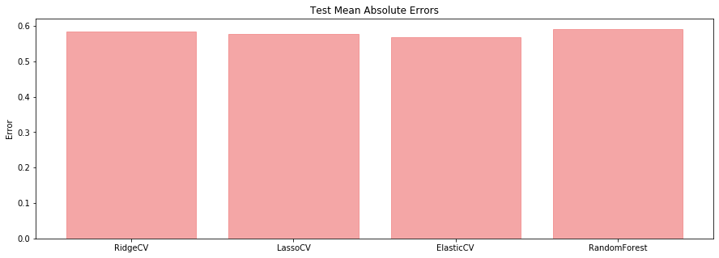

```python
from sklearn.metrics import mean_absolute_error

pred_ridge = ridge.predict(X_test)
pred_lasso = lasso.predict(X_test)
pred_elastic = elastic.predict(X_test)
pred_forest = forest.predict(X_test)

ridge_r2 = mean_absolute_error(Y_test,pred_ridge)
lasso_r2 = mean_absolute_error(Y_test,pred_lasso)
elastic_r2 = mean_absolute_error(Y_test,pred_elastic)
forest_r2 = mean_absolute_error(Y_test,pred_forest)

Models = ("RidgeCV", "LassoCV", "ElasticCV", "RandomForest")
scores = [ridge_r2, lasso_r2, elastic_r2, forest_r2]

plt.figure(1, figsize=(15, 5))
y_pos = np.arange(len(Models))
bargraph=plt.bar(y_pos, scores, alpha=0.7)
plt.xticks(y_pos, Models)
for i in range(len(Models)):
    bargraph[i].set_color('lightcoral')
plt.ylabel('Error')
plt.title('Test Mean Absolute Errors')
plt.show()
```

The Elastic model has a lower test Mean Absolute Error compared to the other models. Lets also compare test r2 scores.

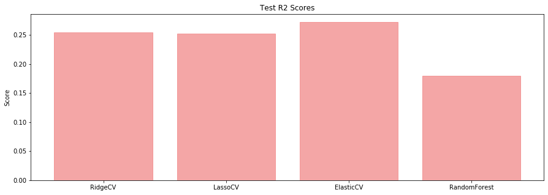

```python
from sklearn.metrics import r2_score

pred_ridge = ridge.predict(X_test)
pred_lasso = lasso.predict(X_test)
pred_elastic = elastic.predict(X_test)
pred_forest = forest.predict(X_test)

ridge_r2 = r2_score(Y_test,pred_ridge)
lasso_r2 = r2_score(Y_test,pred_lasso)
elastic_r2 = r2_score(Y_test,pred_elastic)
forest_r2 = r2_score(Y_test,pred_forest)

Models = ("RidgeCV", "LassoCV", "ElasticCV", "RandomForest")
scores = [ridge_r2, lasso_r2, elastic_r2, forest_r2]

plt.figure(1, figsize=(15, 5))
y_pos = np.arange(len(Models))
bargraph=plt.bar(y_pos, scores, alpha=0.7)
plt.xticks(y_pos, Models)
for i in range(len(Models)):
    bargraph[i].set_color('lightcoral')
plt.ylabel('Score')
plt.title('Test R2 Scores')
plt.show()
```

## Interpretation/Summary

First, let's quickly see how well the ElasticCV predicts the other feautures we were interested in.

```python
X_train, X_test, Y_train, Y_test = train_test_split(X, Y, test_size=0.2)

elastic.fit(X_train, Y_train["NBA_fg%"])
fg_pred = elastic.predict(X_test)
elastic.fit(X_train, Y_train["NBA__3ptpct"])
three_pred = elastic.predict(X_test)
elastic.fit(X_train, Y_train["NBA_ft%"])
ft_pred = elastic.predict(X_test)
elastic.fit(X_train, Y_train["NBA_ppg"])
ppg_pred = elastic.predict(X_test)
```

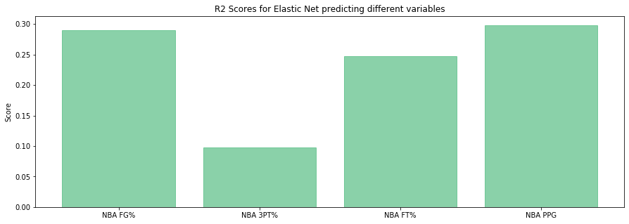

```python
fg_r2 = r2_score(Y_test["NBA_fg%"],fg_pred)
three_r2 = r2_score(Y_test["NBA__3ptpct"],three_pred)
ft_r2 = r2_score(Y_test["NBA_ft%"],ft_pred)
ppg_r2 = r2_score(Y_test["NBA_ppg"],ppg_pred)

Models = ("NBA FG%", "NBA 3PT%", "NBA FT%", "NBA PPG")
scores = [fg_r2, three_r2, ft_r2, ppg_r2]

plt.figure(1, figsize=(15, 5))
y_pos = np.arange(len(Models))
bargraph=plt.bar(y_pos, scores, alpha=0.6)
plt.xticks(y_pos, Models)
for i in range(len(Models)):
    bargraph[i].set_color('mediumseagreen')
plt.ylabel('Score')
plt.title('R2 Scores for Elastic Net predicting different variables')
plt.show()
```

As we can see from this graph, of all the features, the NCAA data is the worst at predicting the 3 Point percentage of players once they reach the NBA. It is decent at predicting Field Goal percentage, Free Throw percentage, and Points Per Game. The relatitvely low r2 score for all of them implies a weak correlation, however.

I was a little surprised by the accuracy of the model and the NCAA data in predicting NBA success, but to a degree it does make some sense. While NCAA performance can be indicative of general basketball skill, a multitude of other factors, including team, injuries, and mentality can play an important role in how successfull a player is in the NBA.

I felt that I correctly chose some models to use for my needs, and it is not surprisign that the models that incorporated regularization did much better than a pure linear model. I was surprised, however, with how poorly the random forest performed in cross validation and test error.

For future work, I would spend more time tuning my models to further reduce the cross validation error. Additionally, I would conduct Principal Component Analysis to determine which of the features played the biggest role in predicting NBA success